# **London Marathon Data Analysis**

```r
library(tidyverse)
library(ggplot2)
library(dplyr)
library(gridExtra)
library(forecast)
remotes::install_github("nrennie/LondonMarathon")
data(winners, package = "LondonMarathon")
data(london_marathon, package = "LondonMarathon")
```

## Introduction

[figure not shown]

The London Marathon, or TCS London Marathon, unites people from all walks of life. Conceived in 1981 by Chris Brasher and John Disley, it’s the UK’s second-largest annual road race. Originally in April, it temporarily moved to October in 2020-2022 due to COVID-19. The flat, scenic course runs along the River Thames, starting at Blackheath and finishing at The Mall.

Beyond being a race, it’s a diverse experience. The mass race welcomes all fitness levels, elite long-distance runners compete, and wheelchair races showcase top-level competition for both men and women.

Since 1981, the marathon has raised over £1 billion for charities. In 2019, a record-breaking £66.4 million was raised, marking it as the highest single-day fundraising event in its history.

*How was the information collected?*

Data seems sourced from official records, the London Marathon’s website, event organizers, media outlets like BBC, and reliable sources associated with the event, compiling information from participant registrations, event statistics, official reports, and media coverage over the years.

**For more details**:

https://en.wikipedia.org/wiki/London_Marathon

Now, let’s dive into the details of the marathon with the comprehensive data:

The “LondonMarathon” package includes two datasets:

- **London Marathon Data:**
  - *Date, Year:* Date and corresponding year of the London Marathon.
  - *Applicants, Accepted:* Count of applicants and accepted participants.
  - *Starters, Finishers:* Participants who started and successfully completed the marathon.
  - *Raised:* Total raised amount during the marathon.
  - *Official Charity:* Designated charity for the year.
- **Winners Data:**
  - *Category, Year:* Winner’s category and the year of the London Marathon.
  - *Athlete, Nationality:* Winning athlete’s name and nationality.
  - *Time:* Duration taken by the winning athlete to complete the marathon.

Cases: 42 in “London Marathon Data,” 165 in “Winners Data.”

#### **Winners Data**

```r
#remotes::install_github("nrennie/LondonMarathon")
library(knitr)
data(winners, package = "LondonMarathon")
kable(head(winners))
```

| Category | Year | Athlete | Nationality | Time |
| --- | --- | --- | --- | --- |
| Men | 1981 | Dick Beardsley (Tie) | United States | 0.09152778 |
| Men | 1981 | Inge Simonsen (Tie) | Norway | 0.09152778 |
| Men | 1982 | Hugh Jones | United Kingdom | 0.08986111 |
| Men | 1983 | Mike Gratton | United Kingdom | 0.09008102 |
| Men | 1984 | Charlie Spedding | United Kingdom | 0.09024306 |
| Men | 1985 | Steve Jones | United Kingdom | 0.08907407 |

#### **London Marathon Data**

```r
library(knitr)
data(london_marathon, package = "LondonMarathon")
kable(head(london_marathon))
```

| Date | Year | Applicants | Accepted | Starters | Finishers | Raised | Official charity |
| --- | --- | --- | --- | --- | --- | --- | --- |
| 1981-03-29 | 1981 | 20000 | 7747 | 7055 | 6255 | NA | NA |
| 1982-05-09 | 1982 | 90000 | 18059 | 16350 | 15116 | NA | NA |
| 1983-04-17 | 1983 | 60000 | 19735 | 16500 | 15793 | NA | NA |
| 1984-05-13 | 1984 | 70000 | 21142 | 16992 | 15675 | NA | NA |
| 1985-04-21 | 1985 | 83000 | 22274 | 17500 | 15873 | NA | NA |
| 1986-04-20 | 1986 | 80000 | 25566 | 19261 | 18067 | NA | British Sports Association for the Disabled (autistic) |

## Data Wrangling

### **Overview of Data**

```r
summary(winners)
```

```
##    Category              Year        Athlete          Nationality
##  Length:165         Min.   :1981   Length:165         Length:165
##  Class :character   1st Qu.:1992   Class :character   Class :character
##  Mode  :character   Median :2002   Mode  :character   Mode  :character
##                     Mean   :2002
##                     3rd Qu.:2012
##                     Max.   :2023
##       Time
##  Min.   :0.06003
##  1st Qu.:0.07581
##  Median :0.08883
##  Mean   :0.08808
##  3rd Qu.:0.09740
##  Max.   :0.18684
```

```r
#kable(summary(winners))
```

The dataset “winners” is free of missing values, and all variables possess suitable data types.

The “Category” column within the Winners dataset consists of four distinct categories: Men, Women, Wheelchair Men, and Wheelchair Women.

```r
unique_categories <- unique(winners$Category)
unique_categories_df <- data.frame(Category = unique_categories)
table_output <- kable(unique_categories_df)
print(table_output)
```

```
##
##
## |Category         |
## |:----------------|
## |Men              |
## |Women            |
## |Wheelchair Men   |
## |Wheelchair Women |
```

### Do variables have appropriate type?

Here is the data types summary.

```r
library(knitr)
table <- data.frame('Column'=c('Category','Year','Athlete','Nationality','Time'), 'Class'=c('character','integer','character','character','character'), 'Description'=c('Category of race','Year','Name of the winner','Nationality of the winner','Winning time'),'Example'=c('Men',1981,'Dick Beardsley(Tie)','United States', '02:11:48'))
kable(table, caption = "Winners Data")
```

Winners Data

[output not shown]

```r
table2 <- data.frame('Column'=c('Date','Year','Applicants','Accepted','Starters','Finishers','Raised','Official.charity'),'Class'=c('character','integer','integer','integer','integer','integer','integer','character'),'Description'=c('Date of the race','Year','Number of people who applied','Number of people accepted','Number of people who started','Number of people who finished','Amount raised for charity(£ millions)','Official charity'),'Example'=c('1981-03-29','1981','20000','7747','7055','6255','46.5','SportsAid'))
kable(table2, caption = "London Marathon Data")
```

London Marathon Data

| Column | Class | Description | Example |
| --- | --- | --- | --- |
| Date | character | Date of the race | 1981-03-29 |
| Year | integer | Year | 1981 |
| Applicants | integer | Number of people who applied | 20000 |
| Accepted | integer | Number of people accepted | 7747 |
| Starters | integer | Number of people who started | 7055 |
| Finishers | integer | Number of people who finished | 6255 |
| Raised | integer | Amount raised for charity(£ millions) | 46.5 |
| Official.charity | character | Official charity | SportsAid |

**Are there any strange aspects to the data?**

In the london_marathon dataset, observation of number of applicants in year 1981-2012 are in a unit of 1000. And observations of number of applicants, accepted, starters, and finishers in year 2020 are abnormally low.

## Winners Data - Analysis & Conclusions

### Anlysis of Winners Dataset

#### Trends in winning times over the year

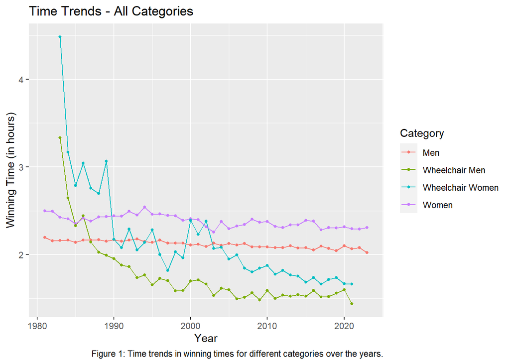

```r
winners_data <- winners |> mutate(Time=24*Time)

winners_data$Year <- as.numeric(winners_data$Year)
winners_data$Time <- as.numeric(winners_data$Time)

# Create time series plots for all categories with captions
ggplot(winners_data, aes(x = Year, y = Time, color = Category)) +
  geom_line() +
  geom_point(size = 1) +
  ggtitle("Time Trends - All Categories") +
  xlab("Year") +
  ylab("Winning Time (in hours)") +
  labs(caption = "Figure 1: Time trends in winning times for different categories over the years.")
```

Athletic performance in the Men and Women categories has shown a consistent improvement, as reflected in decreasing winning times from approximately 0.09 to 0.08 for Men and 0.104 to 0.096 for Women. Wheelchair Men and Wheelchair Women have also experienced significant performance enhancements, with winning times dropping from 0.1389 to 0.06 and 0.1868 to 0.069, respectively. Overall, there is a notable trend of improved performance across all categories, marked by substantial drops in winning times over the years.

### **Compare Winning Times Between Different Categories (Men vs. Women, Wheelchair Men vs. Wheelchair Women)**

**t-test for Men vs. Women**

```r
# t-test for Men vs. Women
t_test_men_women <- t.test(Time ~ Category, data = subset(winners_data, Category %in% c("Men", "Women")))
print(t_test_men_women)
```

```
##
##  Welch Two Sample t-test
##
## data:  Time by Category
## t = -21.25, df = 69.816, p-value < 2.2e-16
## alternative hypothesis: true difference in means between group Men and group Women is not equal to 0
## 95 percent confidence interval:
##  -0.2865984 -0.2374147
## sample estimates:
##   mean in group Men mean in group Women
##            2.121004            2.383010
```

The comparison of average finishing times between Men and Women in the marathon using the Welch Two Sample t-test shows a highly significant result (t-value = -21.25). This means Men, on average, finish the marathon faster than Women. We accounted for differences in variances using Welch’s correction, resulting in approximately 69.816 degrees of freedom.

The p-value is incredibly small (< 2.2e-16), strongly indicating that the mean winning time for Men is significantly different from that of Women. The 95% confidence interval (-0.2865984 to -0.2374147) supports this, as it doesn’t include zero.

The evidence suggests a notable difference, favoring Men, and the average winning time for Men (2.121004) is significantly lower than for Women (2.383010). So, we have strong statistical grounds to reject the idea that there’s no difference, confirming that Men tend to finish the marathon faster than Women.

**t-test for Wheelchair Men vs. Wheelchair Women**

```r
# t-test for Wheelchair Men vs. Wheelchair Women
t_test_wheelchair <- t.test(Time ~ Category, data = subset(winners_data, Category %in% c("Wheelchair Men", "Wheelchair Women")))
print(t_test_wheelchair)
```

```
##
##  Welch Two Sample t-test
##
## data:  Time by Category
## t = -3.684, df = 66.574, p-value = 0.0004625
## alternative hypothesis: true difference in means between group Wheelchair Men and group Wheelchair Women is not equal to 0
## 95 percent confidence interval:
##  -0.6161296 -0.1830727
## sample estimates:
##   mean in group Wheelchair Men mean in group Wheelchair Women
##                       1.761944                       2.161546
```

The t-test results for Wheelchair Men vs. Wheelchair Women reveal a significant difference in mean winning times. The negative t-value (-3.684) suggests that, on average, Wheelchair Women have a higher winning time. The degrees of freedom (df) are 66.574, calculated using Welch’s method.

**ANOVA for Men vs. Women vs. Wheelchair Men vs. Wheelchair Women**

```r
# ANOVA for Men vs. Women vs. Wheelchair Men vs. Wheelchair Women
anova_model <- aov(Time ~ Category, data = subset(winners_data, Category %in% c("Men", "Women", "Wheelchair Men", "Wheelchair Women")))
summary(anova_model)
```

```
##              Df Sum Sq Mean Sq F value   Pr(>F)
## Category      3  8.036   2.679   24.34 4.81e-13 ***
## Residuals   161 17.714   0.110
## ---
## Signif. codes:  0 '***' 0.001 '**' 0.01 '*' 0.05 '.' 0.1 ' ' 1
```

Null Hypothesis (H0): There is no significant difference in mean winning times among the categories. Alternative Hypothesis (H1): There is a significant difference in mean winning times among at least one pair of categories.

I reject the null hypothesis, concluding that there are significant differences in mean winning times across at least one pair of categories (Men, Women, Wheelchair Men, Wheelchair Women). F-Test: The F value of 24.34 is higher than expected by chance, signifying significant differences in mean winning times among categories.

p-value: With a tiny p-value (4.81e-13), there is substantial evidence against the null hypothesis, implying significant differences in mean winning times.

### **Holder’s of the Current Records**

```r
library(knitr)

# Function to find the winner in each category
find_winner <- function(category) {
  min_time <- min(filter(winners, Category == category)$Time)
  winner <- filter(winners, Time == min_time & Category == category)[, c("Category", "Year", "Athlete", "Nationality", "Time")]
  return(winner)
}

# Find winners in each category
winner_men <- find_winner("Men")
winner_women <- find_winner("Women")
winner_wheelchair_men <- find_winner("Wheelchair Men")
winner_wheelchair_women <- find_winner("Wheelchair Women")

# Combine the results into a single table
winners_table <- bind_rows(winner_men, winner_women, winner_wheelchair_men, winner_wheelchair_women)

# Count winners by Category and Nationality
winners_count <- winners_data %>%
  group_by(Category, Nationality) %>%
  summarise(count = n()) %>%
  arrange(desc(count)) %>%
  slice_head()

# Display the combined table
kable(winners_table)
```

| Category | Year | Athlete | Nationality | Time |
| --- | --- | --- | --- | --- |
| Men | 2023 | Kelvin Kiptum | Kenya | 0.08431713 |
| Women | 2003 | Paula Radcliffe | United Kingdom | 0.09403935 |
| Wheelchair Men | 2021 | Marcel Hug | Switzerland | 0.06003472 |
| Wheelchair Women | 2021 | Manuela Schär | Switzerland | 0.06935185 |

### **Winners Count by Category and Nationality**

```r
kable(winners_count)
```

| Category | Nationality | count |
| --- | --- | --- |
| Men | Kenya | 17 |
| Wheelchair Men | United Kingdom | 16 |
| Wheelchair Women | United Kingdom | 15 |
| Women | Kenya | 14 |

## Marathon Dataset - Analysis & Conclusions

When analyzing the London Marathon Data, it was observed that there are instances where certain data points are missing. Specifically, there are 43 occurrences where the information is not available.

```r
cat("Missing Value Count:", sum(is.na(london_marathon)))
```

```
## Missing Value Count: 43
```

### **Percentage Of Missing Values In London Marathon**

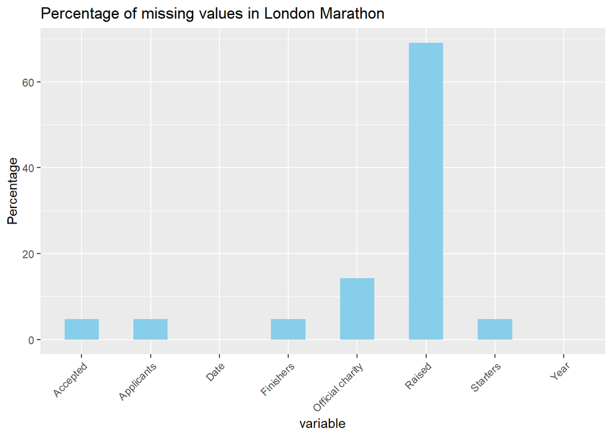

```r
missing_percentage <- colMeans(is.na(london_marathon)) * 100
plot_data <- data.frame(
  variable = names(missing_percentage),
  percentage = missing_percentage
)
ggplot(plot_data, aes(x = variable, y = percentage)) +
  geom_bar(stat = "identity", fill = "skyblue", width = 0.5) +
  labs(title = "Percentage of missing values in London Marathon", y = "Percentage") +
  theme(axis.text.x = element_text(angle = 45, hjust = 1))
```

The London Marathon dataset has missing values, especially in the “Raised” and “Official charity” columns. If “Official charity” is NULL, “Raised” is considered 0.

If “Official charity” is present and “Raised” is missing, the value can be filled with the average of other data. Additionally, missing values in other fields are consistent and likely due to the absence of data for the last two years, as per official documentation on Github.

It’s advisable to exclude entries from these two years in the analysis.

**Data Cleaning and Imputation for London Marathon Dataset**

After performing thorough data cleaning and imputation processes on the London Marathon Dataset, it is noteworthy that the dataset is now free from missing values, and the count of missing values has been reduced to 0.

```r
london_marathon1 <- london_marathon %>% group_by(`Official charity`) %>% mutate(Raised=ifelse(is.na(Raised) & !is.na(`Official charity`), mean(london_marathon$Raised, na.rm=T), Raised))

london_marathon1 <- london_marathon1 %>% mutate(Raised=ifelse(is.na(`Official charity`), 0, Raised))

london_marathon1 <- london_marathon1 %>% mutate(`Official charity`=ifelse(is.na(`Official charity`), "None", `Official charity`))

london_marathon1 <- london_marathon1 %>% filter(Year < max(london_marathon1$Year) - 1)

cat("New Missing Value Count:", sum(is.na(london_marathon1)))
```

```
## New Missing Value Count: 0
```

### **Filled Raised Data Chart**

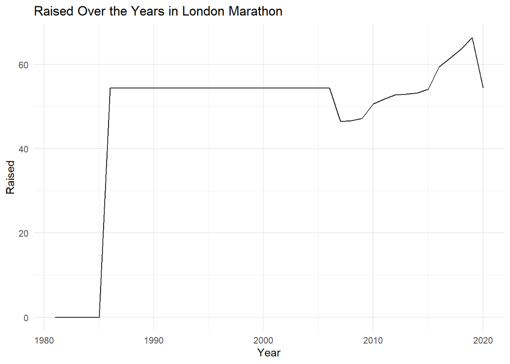

```r
ggplot(london_marathon1, aes(x = Year, y = Raised)) +
  geom_line() +
  labs(title = "Raised Over the Years in London Marathon",
       x = "Year",
       y = "Raised") +
  theme_minimal()
```

The filled Raised data in the line chart doesn’t provide useful insights for analyzing the changes. To better focus on this aspect, **we should narrow our attention to the data spanning from 2007 to 2019.**

```r
filter_data <- london_marathon1 %>% filter(Year >= 2007 & Year <= 2019)
```

#### **Filtered Line Chart: Changes in Raised Data (2007-2019)**

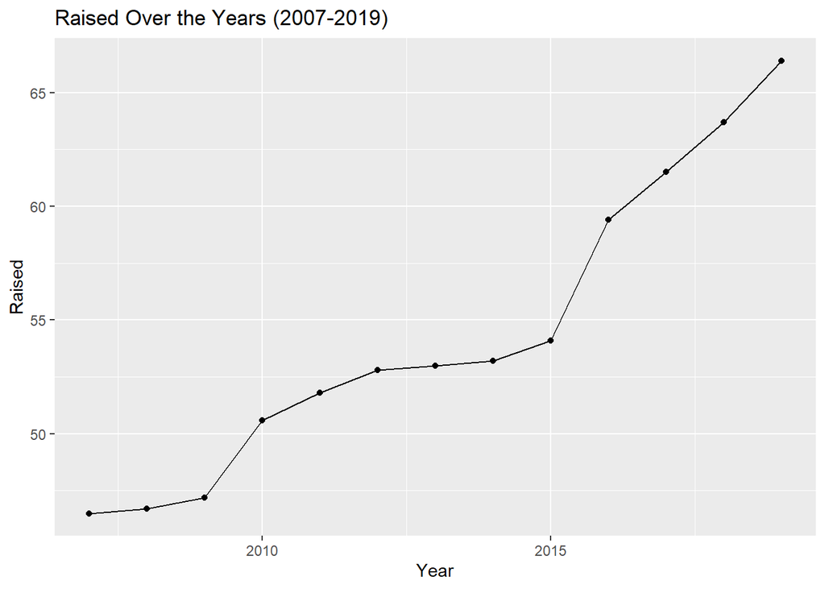

```r
ggplot(filter_data, aes(x=Year, y=Raised, group=1))+
  geom_line() +
  geom_point() +
  labs(title = "Raised Over the Years (2007-2019)",
     x = "Year",
     y = "Raised") +
  theme()
```

### Calculate The Percentage Of Accepted Participants Who Started Race And The Percentage Of Starters Who Finished.

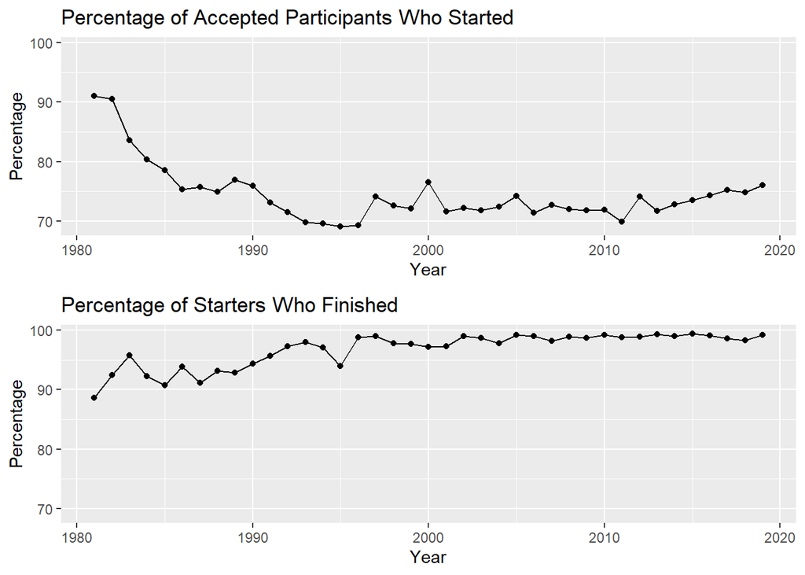

```r
# Load data
winners_data <- read.csv("winners.csv")
marathon_data <- read.csv("london_marathon.csv")

library(gridExtra)

# Calculate the percentage of accepted participants who started
marathon_data$Accepted_to_Started <- (marathon_data$Starters / marathon_data$Accepted) * 100

# Calculate the percentage of starters who finished
marathon_data$Started_to_Finished <- (marathon_data$Finishers / marathon_data$Starters) * 100

# Subset the data for plotting (adjust the range as needed)
sub_marathon_data <- marathon_data[1:39,]

# Calculate common y-axis limits
common_ylim <- range(c(sub_marathon_data$Accepted_to_Started, sub_marathon_data$Started_to_Finished))

# Print the results
#print(marathon_data[, c("Year", "Accepted_to_Started", "Started_to_Finished")])

# Plotting
p1 <- ggplot(data = sub_marathon_data, aes(x = Year, y = Accepted_to_Started)) +
  geom_point() +
  geom_line() +
  labs(title = "Percentage of Accepted Participants Who Started",
       x = "Year",
       y = "Percentage") +
  ylim(common_ylim)

p2 <- ggplot(data = sub_marathon_data, aes(x = Year, y = Started_to_Finished)) +
  geom_point() +
  geom_line() +
  labs(title = "Percentage of Starters Who Finished",
       x = "Year",
       y = "Percentage") +
  ylim(common_ylim)

# Arrange the plots in a grid
grid.arrange(p1, p2, nrow = 2, ncol = 1)
```

**Accepted to Started:**

### Exploring Distribution Of Winners By Nationality In London Marathon Data

```r
library(tidyverse)
library(knitr)


# Group winners data by Nationality and calculate the count
winners_plot <- winners %>%
  group_by(Nationality) %>%
  summarise(Count = n())

# Arrange the data in descending order based on the count
winners_plot <- winners_plot %>%
  arrange(desc(Count))

# Print the top 3 countries using kable
top_3_countries <- head(winners_plot, 3)
kable(top_3_countries)
```

| Nationality | Count |
| --- | --- |
| United Kingdom | 44 |
| Kenya | 31 |
| United States | 11 |